## Data Science: Reproducible Research - Final Project

### **Title:** Most harmful Weather Events on Population Health and Economy in the United States

#### **Synopsis**

The aim of this report is to analyze impact of different weather events on United States population health & economy. This analysis is done exploration of the Storm database collected from the U.S. National Oceanic and Atmospheric Administration’s (NOAA).

In this report, we aim to analyze the impact of different weather events on public health and economy based on the storm database collected from the U.S. National Oceanic and Atmospheric Administration’s (NOAA) from 1950 - 2011. We will use the estimates of fatalities, injuries, property and crop damage to decide which types of events are most impactful to the U.S. population health and economy. Analysis indicate tornado and excessive heat are most impactful with respect to population health. Similarly flood, hurricane/typhoon, tornado, and storm surge have the highest impact on the economy

#### **Data Processing**

The storm data should be downloaded if it’s not present already in the data directory. Storm data is available at [this location](https://d396qusza40orc.cloudfront.net/repdata%2Fdata%2FStormData.csv.bz2)

```r
echo = TRUE
cache = TRUE
setwd("/Users/jagan/work/DataScience/ReproducibleResearch/DataScience-ReproducibleResearch-FinalProject")
if (!file.exists("data/StormData.csv.bz2")) {
    dir.create("data", showWarnings = FALSE) #ignore Warning to recreate the directory
    fileUrl <- "https://d396qusza40orc.cloudfront.net/repdata%2Fdata%2FStormData.csv.bz2"
    download.file(fileUrl, destfile = "data/stormData.csv.bz2")
}
```

As the file is compressed with bzip2 (extension .bz2) it can be read by read.csv without having to uncompress so that disk space is saved and also reading too much data from disk is avoided

```r
stormData <- read.csv("data/stormData.csv.bz2")
dim(stormData)
```

```
## [1] 902297     37
```

```r
names(stormData)
```

```
##  [1] "STATE__"    "BGN_DATE"   "BGN_TIME"   "TIME_ZONE"  "COUNTY"
##  [6] "COUNTYNAME" "STATE"      "EVTYPE"     "BGN_RANGE"  "BGN_AZI"
## [11] "BGN_LOCATI" "END_DATE"   "END_TIME"   "COUNTY_END" "COUNTYENDN"
## [16] "END_RANGE"  "END_AZI"    "END_LOCATI" "LENGTH"     "WIDTH"
## [21] "F"          "MAG"        "FATALITIES" "INJURIES"   "PROPDMG"
## [26] "PROPDMGEXP" "CROPDMG"    "CROPDMGEXP" "WFO"        "STATEOFFIC"
## [31] "ZONENAMES"  "LATITUDE"   "LONGITUDE"  "LATITUDE_E" "LONGITUDE_"
## [36] "REMARKS"    "REFNUM"
```

```r
head(stormData, n = 2)
```

```
##   STATE__          BGN_DATE BGN_TIME TIME_ZONE COUNTY COUNTYNAME STATE
## 1       1 4/18/1950 0:00:00     0130       CST     97     MOBILE    AL
## 2       1 4/18/1950 0:00:00     0145       CST      3    BALDWIN    AL
##    EVTYPE BGN_RANGE BGN_AZI BGN_LOCATI END_DATE END_TIME COUNTY_END
## 1 TORNADO         0                                               0
## 2 TORNADO         0                                               0
##   COUNTYENDN END_RANGE END_AZI END_LOCATI LENGTH WIDTH F MAG FATALITIES
## 1         NA         0                        14   100 3   0          0
## 2         NA         0                         2   150 2   0          0
##   INJURIES PROPDMG PROPDMGEXP CROPDMG CROPDMGEXP WFO STATEOFFIC ZONENAMES
## 1       15    25.0          K       0
## 2        0     2.5          K       0
##   LATITUDE LONGITUDE LATITUDE_E LONGITUDE_ REMARKS REFNUM
## 1     3040      8812       3051       8806              1
## 2     3042      8755          0          0              2
```

```r
head(stormData$BGN_DATE, n=1)
```

```
## [1] 4/18/1950 0:00:00
## 16335 Levels: 1/1/1966 0:00:00 1/1/1972 0:00:00 ... 9/9/2011 0:00:00
```

```r
tail(stormData$BGN_DATE, n=1)
```

```
## [1] 11/28/2011 0:00:00
## 16335 Levels: 1/1/1966 0:00:00 1/1/1972 0:00:00 ... 9/9/2011 0:00:00
```

We can see that totally 902297 rows with each row having 37 columns. Events are captured between 4/18/1950 and 11/28/2011. As the goal is to estimate the health and economy impacts only relevant fields are extracted. The fields being extracted are **EVTYPE**, **FATALITIES**, **INJURIES**, **PROPDMG**, **PROPDMGEXP**, **CROPDMG**, **CROPDMGEXP**. Also based on the information available [Storm Schema](http://ire.org/media/uploads/files/datalibrary/samplefiles/Storm%20Events/layout08.doc) the PROPDMGEXP is used as an unit to multiply the value of PROPDMG and similarly CORPDMGEXP is used for getting the CROPDMG in same units (USD)

There are very few PROPDMGEXP values which are numeric and for such scenarios no special treatment is done as there is no explanation on how to handle such values. The values being handled are EMPTY string, K, m, M, B. For EMPTY & other PROPDMGEXP scenarios PROPDMG is used as-is. Similar rules are applied for CROPDMGEXP too while deriving an absolute value of CROPDMG

Its also observed that there are no NA values for any of these fields and hence we don’t need to ignore any NA values

```r
# capture only relevant fields for our analysis
stormData <- stormData[ , c("EVTYPE", "FATALITIES", "INJURIES", "PROPDMG", "PROPDMGEXP", "CROPDMG", "CROPDMGEXP")]

# convert the Property Damage value into common denomination (USD)
stormData$PROPDMG[stormData$PROPDMGEXP==""] <- stormData$PROPDMG[stormData$PROPDMGEXP==""]
stormData$PROPDMG[toupper(stormData$PROPDMGEXP)=="H"] <- stormData$PROPDMG[toupper(stormData$PROPDMGEXP)=="H"]*1e2
stormData$PROPDMG[toupper(stormData$PROPDMGEXP)=="K"] <- stormData$PROPDMG[toupper(stormData$PROPDMGEXP)=="K"]*1e3
stormData$PROPDMG[toupper(stormData$PROPDMGEXP)=="M"] <- stormData$PROPDMG[toupper(stormData$PROPDMGEXP)=="M"]*1e6
stormData$PROPDMG[toupper(stormData$PROPDMGEXP)=="B"] <- stormData$PROPDMG[toupper(stormData$PROPDMGEXP)=="B"]*1e9

# convert the Crop Damage value into common denomination (USD)
stormData$CROPDMG[stormData$CROPDMGEXP==""] <- stormData$CROPDMG[stormData$CROPDMGEXP==""]
stormData$CROPDMG[toupper(stormData$CROPDMGEXP)=="H"] <- stormData$CROPDMG[toupper(stormData$CROPDMGEXP)=="H"]*1e2
stormData$CROPDMG[toupper(stormData$CROPDMGEXP)=="K"] <- stormData$CROPDMG[toupper(stormData$CROPDMGEXP)=="K"]*1e3
stormData$CROPDMG[toupper(stormData$CROPDMGEXP)=="M"] <- stormData$CROPDMG[toupper(stormData$CROPDMGEXP)=="M"]*1e6
stormData$CROPDMG[toupper(stormData$CROPDMGEXP)=="B"] <- stormData$CROPDMG[toupper(stormData$CROPDMGEXP)=="B"]*1e9
```

##### Impact on Population Health

In this we generate the top 10 weather events that resulted in high number of fatalities and injuries

```r
# generate the top 10 health impacting events
healthImpact <- aggregate(cbind(FATALITIES, INJURIES) ~ EVTYPE, stormData, sum, na.rm = TRUE)
healthImpact$TOTAL <- with(healthImpact, FATALITIES + INJURIES)
top10HealthImpacts <- head(healthImpact[order(healthImpact$TOTAL, decreasing=TRUE),], 10)
top10HealthImpacts
```

```
##                EVTYPE FATALITIES INJURIES TOTAL
## 834           TORNADO       5633    91346 96979
## 130    EXCESSIVE HEAT       1903     6525  8428
## 856         TSTM WIND        504     6957  7461
## 170             FLOOD        470     6789  7259
## 464         LIGHTNING        816     5230  6046
## 275              HEAT        937     2100  3037
## 153       FLASH FLOOD        978     1777  2755
## 427         ICE STORM         89     1975  2064
## 760 THUNDERSTORM WIND        133     1488  1621
## 972      WINTER STORM        206     1321  1527
```

##### Impact on Economy

In this we generate the top 10 weather events that resulted in high Property & Crop Damages

```r
# generate the top 10 economy impacting events
economyImpact <- aggregate(cbind(PROPDMG, CROPDMG) ~ EVTYPE, stormData, sum, na.rm = TRUE)
economyImpact$TOTAL <- with(economyImpact, PROPDMG+CROPDMG)
top10EconomyImpacts <- head(economyImpact[order(economyImpact$TOTAL, decreasing=TRUE),], 10)
top10EconomyImpacts
```

```
##                EVTYPE      PROPDMG     CROPDMG        TOTAL
## 170             FLOOD 144657709807  5661968450 150319678257
## 411 HURRICANE/TYPHOON  69305840000  2607872800  71913712800
## 834           TORNADO  56937160779   414953270  57352114049
## 670       STORM SURGE  43323536000        5000  43323541000
## 244              HAIL  15732267543  3025954473  18758222016
## 153       FLASH FLOOD  16140812067  1421317100  17562129167
## 95            DROUGHT   1046106000 13972566000  15018672000
## 402         HURRICANE  11868319010  2741910000  14610229010
## 590       RIVER FLOOD   5118945500  5029459000  10148404500
## 427         ICE STORM   3944927860  5022113500   8967041360
```

#### Results

In the following graph we plot the total number of Fatalities & Injuries against the weather events for the top 10 health impacting events

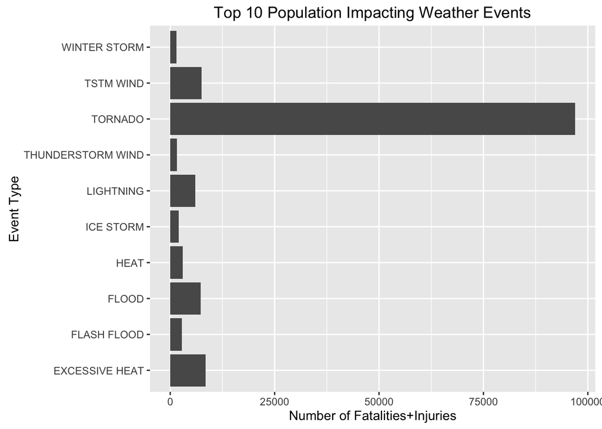

```r
library(ggplot2)
g <- ggplot(top10HealthImpacts, aes(EVTYPE, TOTAL))
g + geom_bar(stat = "identity") + coord_flip() + labs(x = "Event Type",
                                                      y = "Number of Fatalities+Injuries",
                                                      title = "Top 10 Population Impacting Weather Events")
```

In the following graph we plot the total impact on the economy (in terms of total damage to Property & Crop) against the weather events for the top 10 economy impacting events

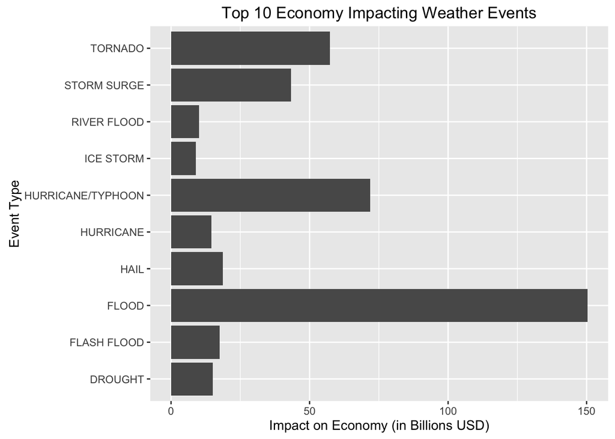

```r
# convert the economy impact amount to Billions for readability
top10EconomyImpacts$TOTAL <- top10EconomyImpacts$TOTAL/1e9

g <- ggplot(top10EconomyImpacts, aes(EVTYPE, TOTAL))
g + geom_bar(stat = "identity") + coord_flip() + labs(x = "Event Type",
                                                      y = "Impact on Economy (in Billions USD)",
                                                      title = "Top 10 Economy Impacting Weather Events")
```

Following are the summary of this analysis

1. **Tornado** and **excessive heat** are the primary reasons affecting the population health
2. **Flood**, **hurricane**, **tornado**, and **storm surge** are the primary reasons affecting the economy